# 8-8-1 checks

Katie Uzzell

05/09/2023

## **8-8-1 update summary**

Data for to 2021/22 have been created and saved as 2023-09-11_8-8-1.csv in the 8-8-1 Output folder.

### **Check configurations**

Please check that the information below is as you expect. In particular, pay attention to the time since data were saved, to check that previously downloaded data have not accidentally been used.

These settings can all be adjusted in `config.R`

Files used to create the new data were downloaded and saved in 8-8-1/Example_Input.

**Fatal and non-fatal workplace injuries data from Health and Safety Executive (HSE)**

Fatal workplace injury headline data are saved in the ridhist.xlsx. This file was saved at 2023-09-11 07:23:14: It has been 0.07 days since the file was saved in Example_Input.

Fatal workplace injury by region data are saved in the ridreg.xlsx.This file was saved at 2023-09-11 07:23:14: It has been 0.07 days since the file was saved in Example_Input.

Fatal workplace injury by age and sex data are saved in the ridagegen.xlsx. This file was saved at 2023-09-11 07:23:14: It has been 0.07 days since the file was saved in Example_Input.

Non-fatal workplace injury headline data data are saved in the lfsinjsum.xlsx. This file was saved at 2023-09-11 07:23:14: It has been 0.07 days since the file was saved in Example_Input.

Non-fatal workplace injury by region data are saved in the lfsinjreg.xlsx. This file was saved at 2023-09-11 07:23:14: It has been 0.07 days since the file was saved in Example_Input.

Non-fatal workplace injury by age and sex data are saved in the lfsinjage.xlsx. This file was saved at 2023-09-11 07:23:14: It has been 0.07 days since the file was saved in Example_Input.

Non-fatal workplace injury by industry data are saved in the lfsinjind.xlsx. This file was saved at 2023-09-11 07:23:14: It has been 0.07 days since the file was saved in Example_Input.

Non-fatal workplace injury by occupation data are saved in the lfsinjocc.xlsx. This file was saved at 2023-09-11 07:23:14: It has been 0.07 days since the file was saved in Example_Input.

**The tab used for all fatal injury inputs is called Table 1.**

**The tab used for all non-fatal injury inputs is called Table-1.**

## **Check data**

Please check the graphs below for any differences between the live and new data. If there are differences visible in the graphs below, please investigate these.

### **Fatal injuries data**

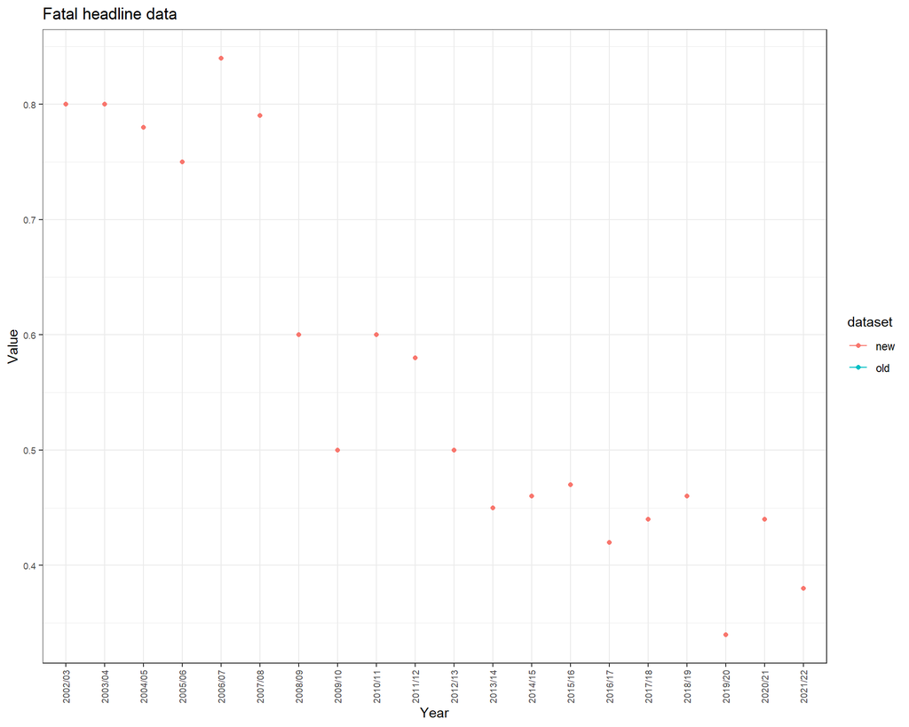

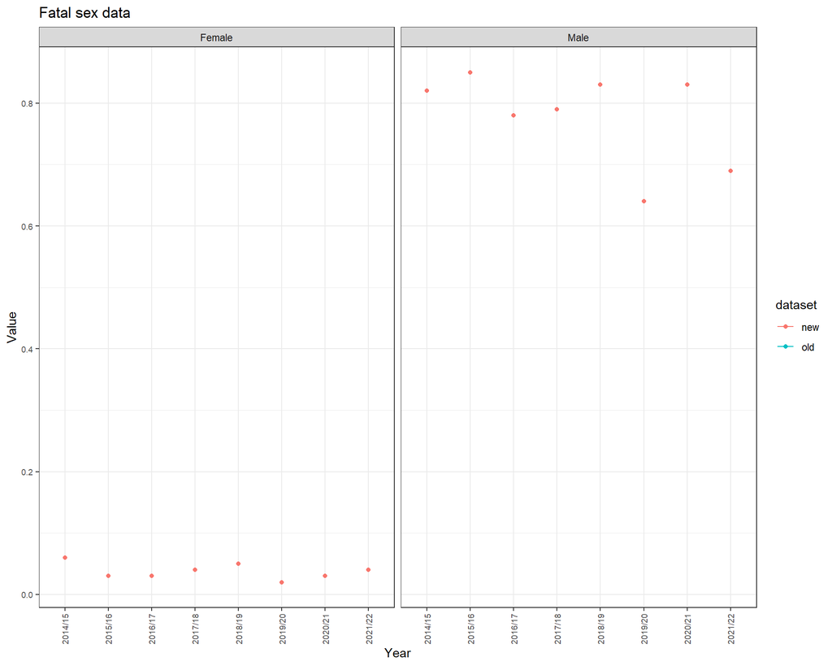

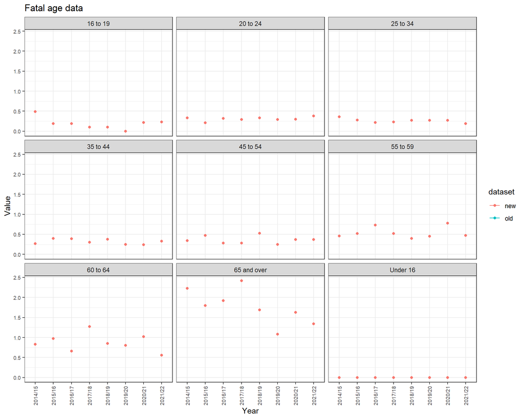

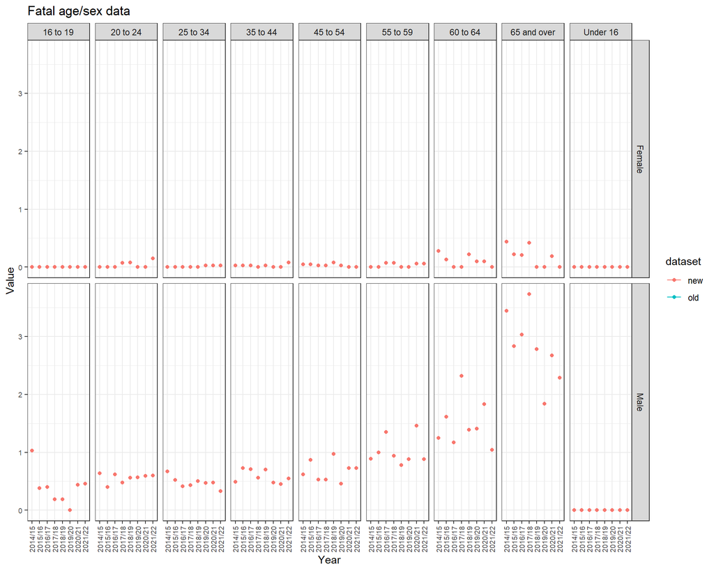

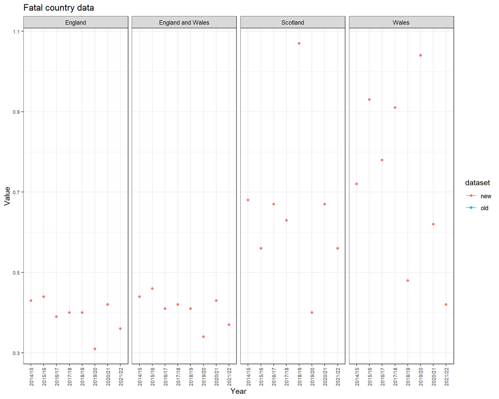

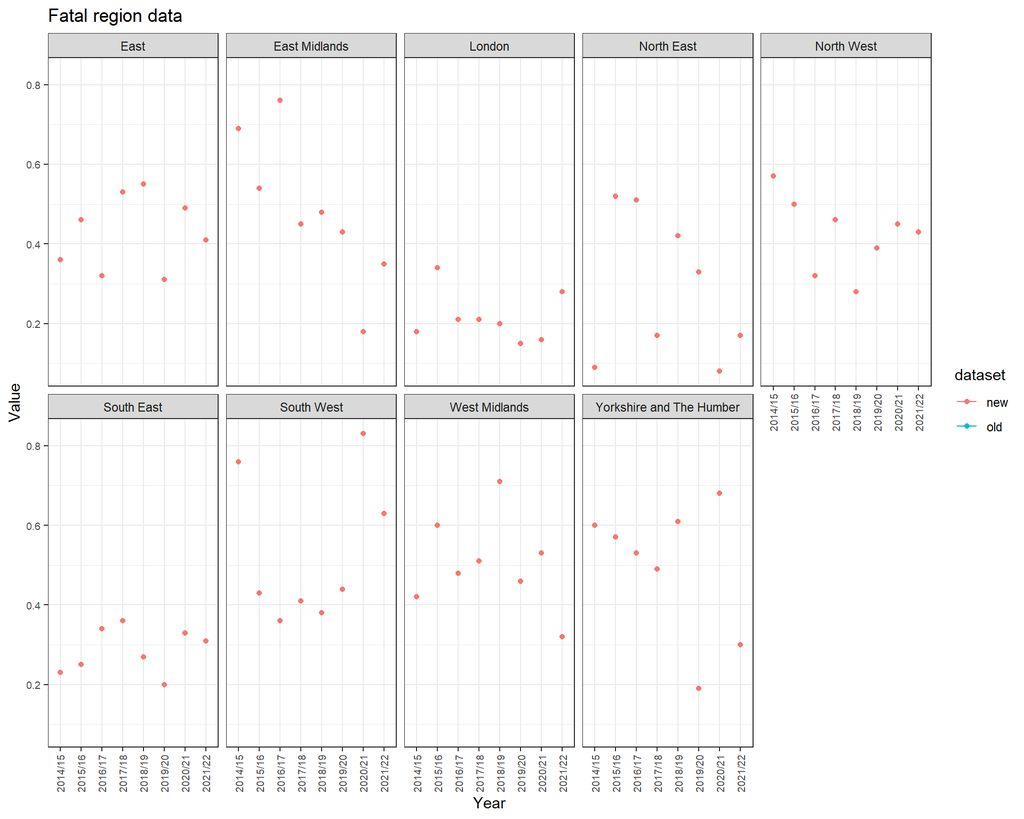

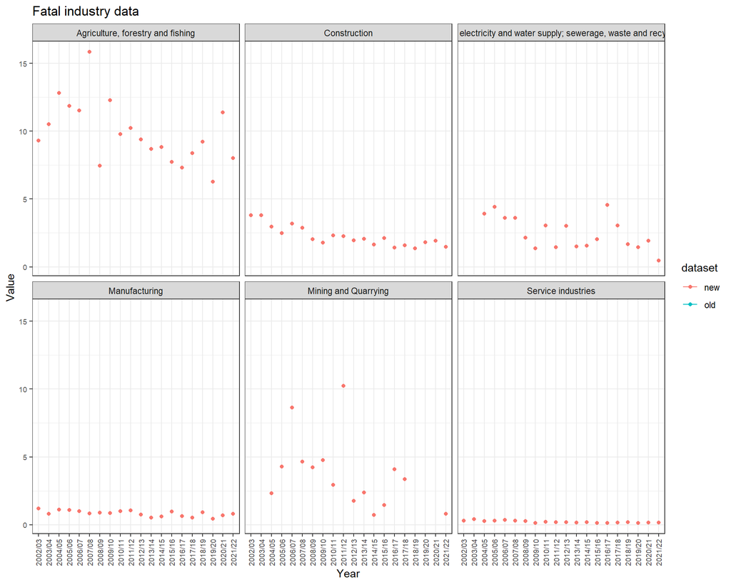

### **Non-fatal injuries data**

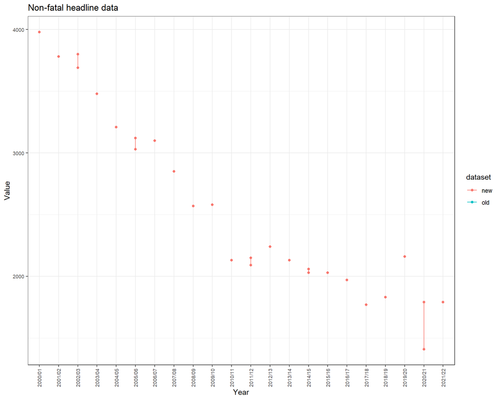

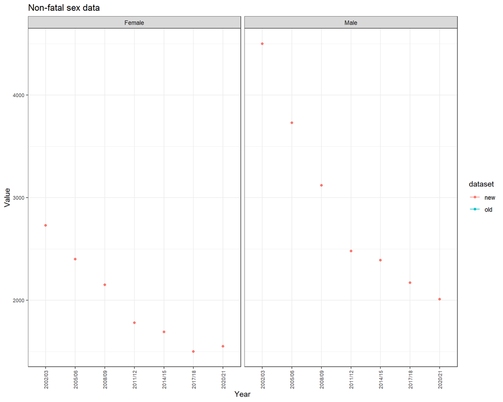

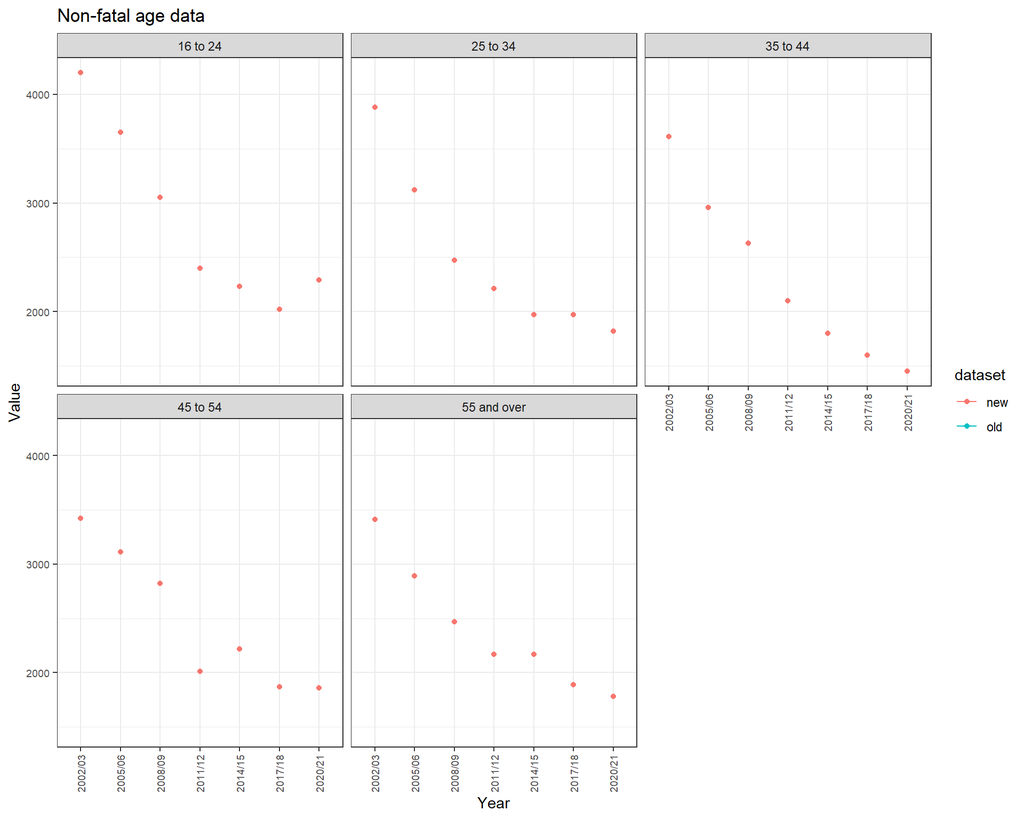

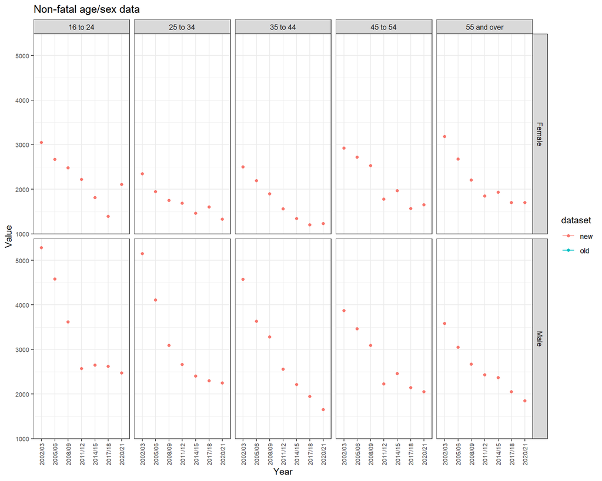

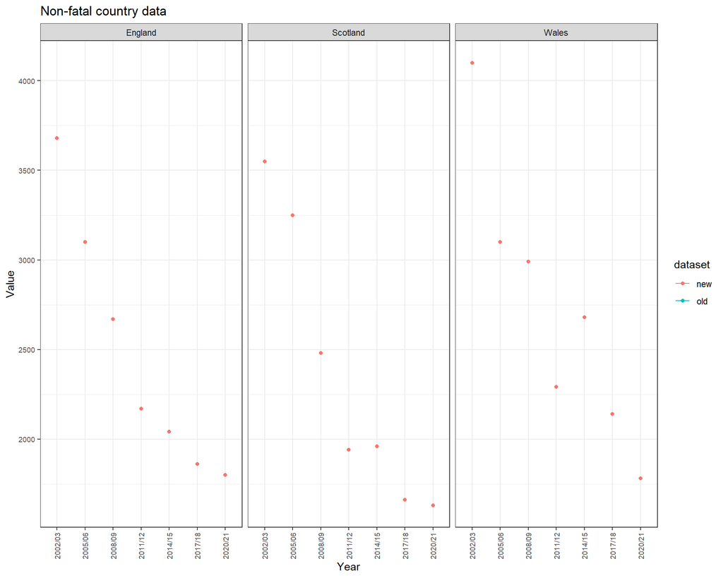

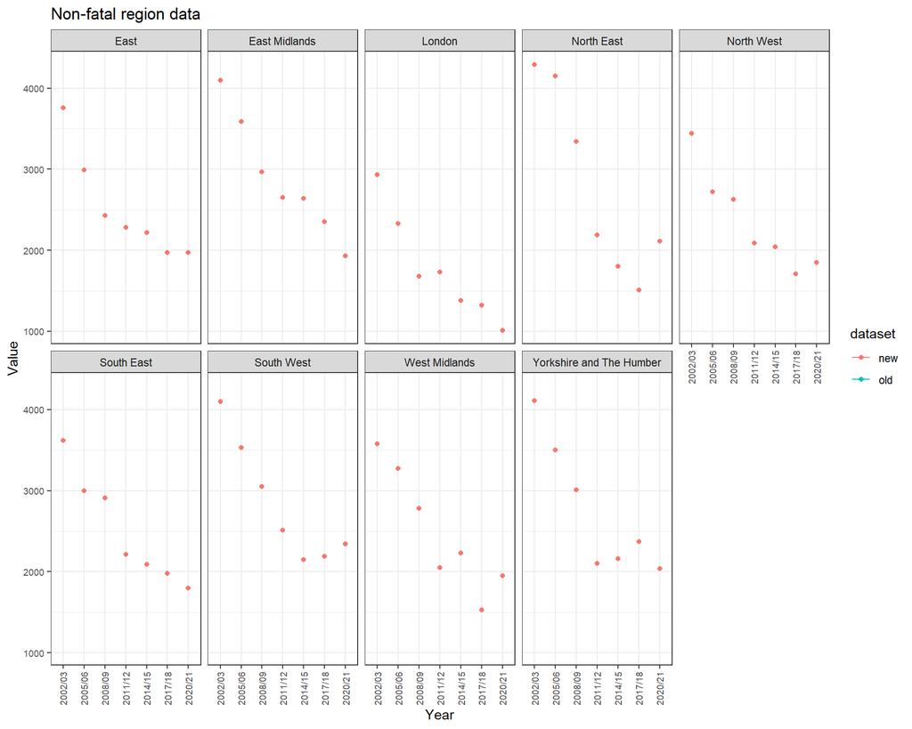

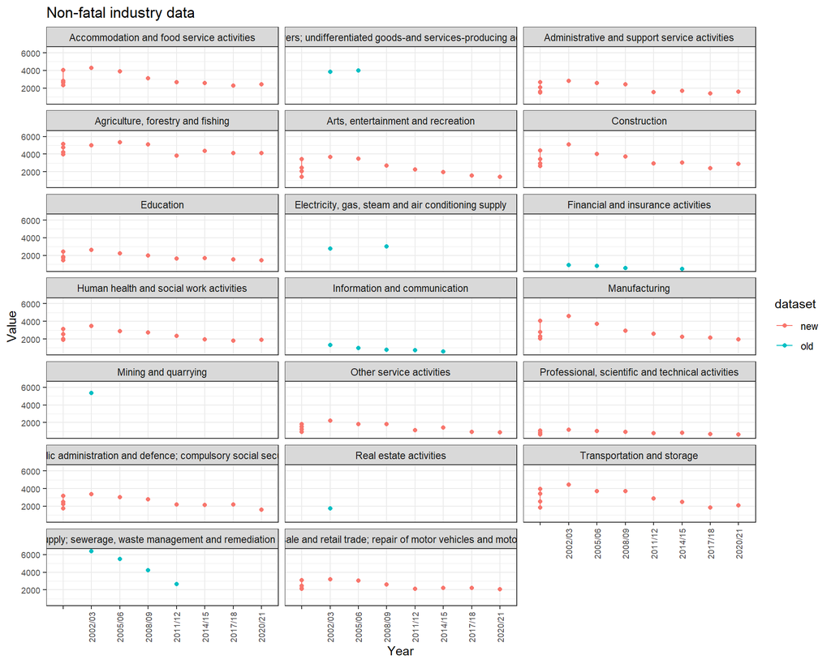

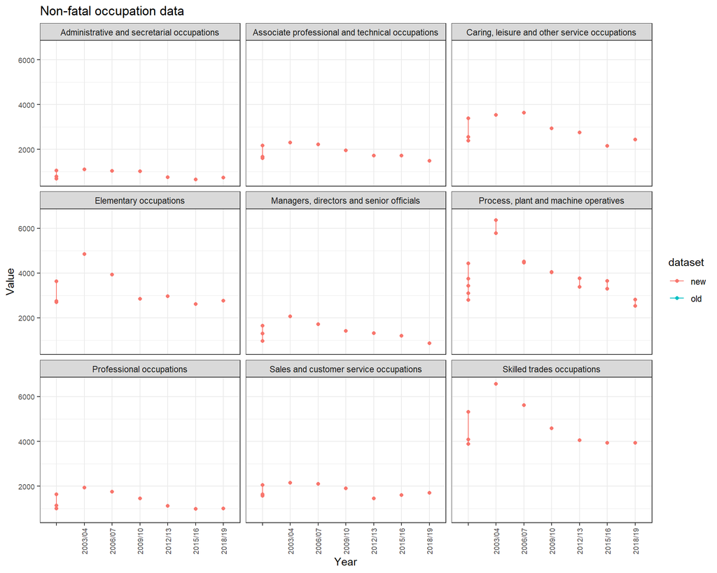

## **Calculations**

No calculations were performed on this data during the automated update.

**R version 4.1.3 (2022-03-10)**

**Platform:** x86_64-w64-mingw32/x64 (64-bit)

**locale:** *LC_COLLATE=English_United Kingdom.1252*, *LC_CTYPE=English_United Kingdom.1252*, *LC_MONETARY=English_United Kingdom.1252*, *LC_NUMERIC=C* and *LC_TIME=English_United Kingdom.1252*

**attached base packages:** *stats*, *graphics*, *grDevices*, *utils*, *datasets*, *methods* and *base*

**other attached packages:** *DT(v.0.25)*, *pander(v.0.6.5)*, *kableExtra(v.1.3.4)*, *ggplot2(v.3.3.6)*, *SDGupdater(v.0.0.0.9000)*, *lubridate(v.1.8.0)*, *dplyr(v.1.0.10)*, *tidyr(v.1.2.1)*, *janitor(v.2.1.0)*, *stringr(v.1.4.1)* and *openxlsx(v.4.2.5)*

**loaded via a namespace (and not attached):** *tidyselect(v.1.1.2)*, *xfun(v.0.33)*, *bslib(v.0.4.0)*, *purrr(v.0.3.4)*, *snakecase(v.0.11.0)*, *colorspace(v.2.0-3)*, *vctrs(v.0.4.2)*, *generics(v.0.1.3)*, *htmltools(v.0.5.3)*, *viridisLite(v.0.4.1)*, *yaml(v.2.3.5)*, *utf8(v.1.2.2)*, *rlang(v.1.0.6)*, *jquerylib(v.0.1.4)*, *pillar(v.1.8.1)*, *glue(v.1.6.2)*, *withr(v.2.5.0)*, *DBI(v.1.1.3)*, *lifecycle(v.1.0.2)*, *munsell(v.0.5.0)*, *gtable(v.0.3.1)*, *rvest(v.1.0.3)*, *zip(v.2.2.1)*, *htmlwidgets(v.1.5.4)*, *evaluate(v.0.16)*, *labeling(v.0.4.2)*, *knitr(v.1.40)*, *fastmap(v.1.1.0)*, *fansi(v.1.0.3)*, *highr(v.0.9)*, *Rcpp(v.1.0.9)*, *scales(v.1.2.1)*, *cachem(v.1.0.6)*, *webshot(v.0.5.4)*, *jsonlite(v.1.8.1)*, *farver(v.2.1.1)*, *systemfonts(v.1.0.4)*, *digest(v.0.6.29)*, *stringi(v.1.7.6)*, *grid(v.4.1.3)*, *cli(v.3.4.1)*, *tools(v.4.1.3)*, *magrittr(v.2.0.3)*, *sass(v.0.4.2)*, *tibble(v.3.1.8)*, *pkgconfig(v.2.0.3)*, *ellipsis(v.0.3.2)*, *xml2(v.1.3.3)*, *assertthat(v.0.2.1)*, *rmarkdown(v.2.16)*, *svglite(v.2.1.0)*, *httr(v.1.4.4)*, *rstudioapi(v.0.14)*, *R6(v.2.5.1)* and *compiler(v.4.1.3)*